# Data Tidying

## 3.1 Why tidy data?

> “**Happy families** are all alike; every **unhappy family** is unhappy in its own way.” — Leo Tolstoy

> “**Tidy datasets** are all alike, but every **untidy dataset** is untidy in its own way.” — Hadley Wickham
- Die Bereinigung der Daten erfordert im Vorfeld einige Arbeit, ist aber auf lange Sicht hilfreich
- wenn wir einmal aufgeräumte Daten haben, werden wir weniger Zeit damit verbringen, die Daten in die richtige Form zu bringen, um das zu tun, was wir wollen

Die Arbeit mit aufgeräumten Daten hat zwei wesentliche Vorteile:

1. Die Arbeit mit einer konsistenten Datenstruktur ermöglicht es uns, Konventionen zu übernehmen.
   - Da aufgeräumte Daten die allgemein anerkannte Datenstruktur sind, basieren die Konventionen auf der Annahme dieser Struktur.
   - Werkzeuge haben also eine zugrundeliegende Einheitlichkeit
2. Die vektorisierte Natur von R kann glänzen
   - Die meisten eingebauten R-Funktionen arbeiten mit *Vektorwerten*.
   - Alle Pakete im “Tidyverse” sind für die Arbeit mit Tidy-Daten konzipiert.

**Vectors**

Vectors are the most basic data object type in R. A vector contains data of the same type, and is essentially a list. You can create a vector using the `c()` function, for example.

```r
vector1 <- c(2, 3, 4, 6, 7)
vector2 <- c(2, 3, 4, 6, "c")
```

`vector1` will contain numeric values, because all elements are numbers. `vector2` will contain all character values (i.e., text), because there is a singlular unambiguous character element (`"c"`). So, R reads all elements as character type. We can create a dataframe from vectors of the same length using the `tibble()` function, for example.

```r
tibble(vector1,vector2)
```

```
# A tibble: 5 × 2
  vector1 vector2
    <dbl> <chr>
1       2 2
2       3 3
3       4 4
4       6 6
5       7 c
```

- most data “in the wild” is untidy
  - data is often first organised for some goal other than analysis
    - usually this goal is data entry: we want to make it easy to document our observations first
  - most people aren’t familiar with the principles of tidy data, only after spending *a lot* of time with data does it become obvious why tidy data is necessary
- this means most *real* analyses will require at least some tidying

**Aufgabe 1: Tidy data**

**Beispiel 1**

# 4 Data tidying

- re-shaping
  - e.g., from wide to long data
- outcome:
  - each column = a variable
  - each row = an observation

## 4.1 Data tidying with the `tidyverse`

- with `tidyr` package
  - `pivot_longer()`: make wide data longer
  - `pivot_wider()`: make long data wider
- we often need to convert between these formats to do different types of summaries or visualisation

[figure not shown]

Abbildung 1: die berühmteste Verwendung des Wortes Pivot (zumindest für Millenials) ([Friends](https://www.youtube.com/watch?v=8w3wmQAMoxQ))

# 5 Wide versus long data

- Wide data: all of the observations about one thing are in the same row
  - wide data is *usually* not tidy
- long data: each observation is on a separate row
  - long data is *usually* tidy

# 6 Lengthening data: `df_billboard`

- in the `billboard.csv` dataset
  - each row is a song
  - the first three columns are variables that describe the song (`artist`, `track`, `date_entered`)
  - we have 76 columns (`wk1-wk76`) that describe the rank of the song that week
    - the columns names are one variable (the `week`), and the cell values are another variable (the `rank`)

```r
df_billboard %>%
  head() %>%
  knitr::kable() %>%
  kableExtra::kable_styling()
```

Tabelle 1: df_billboard rank of songs in the year 2000

| artist | track | date_entered | wk1 | wk2 | wk3 | wk4 | wk5 | wk6 | wk7 | wk8 | wk9 | wk10 | wk11 | wk12 | wk13 | wk14 | wk15 | wk16 | wk17 | wk18 | wk19 | wk20 | wk21 | wk22 | wk23 | wk24 | wk25 | wk26 | wk27 | … |
| --- | --- | --- | --- | --- | --- | --- | --- | --- | --- | --- | --- | --- | --- | --- | --- | --- | --- | --- | --- | --- | --- | --- | --- | --- | --- | --- | --- | --- | --- | --- |
| 2 Pac | Baby Don't Cry (Keep... | 2000-02-26 | 87 | 82 | 72 | 77 | 87 | 94 | 99 | NA | NA | NA | NA | NA | NA | NA | NA | NA | NA | NA | NA | NA | NA | NA | NA | NA | NA | NA | NA | … |
| 2Ge+her | The Hardest Part Of ... | 2000-09-02 | 91 | 87 | 92 | NA | NA | NA | NA | NA | NA | NA | NA | NA | NA | NA | NA | NA | NA | NA | NA | NA | NA | NA | NA | NA | NA | NA | NA | … |
| 3 Doors Down | Kryptonite | 2000-04-08 | 81 | 70 | 68 | 67 | 66 | 57 | 54 | 53 | 51 | 51 | 51 | 51 | 47 | 44 | 38 | 28 | 22 | 18 | 18 | 14 | 12 | 7 | 6 | 6 | 6 | 5 | 5 | … |
| 3 Doors Down | Loser | 2000-10-21 | 76 | 76 | 72 | 69 | 67 | 65 | 55 | 59 | 62 | 61 | 61 | 59 | 61 | 66 | 72 | 76 | 75 | 67 | 73 | 70 | NA | NA | NA | NA | NA | NA | NA | … |
| 504 Boyz | Wobble Wobble | 2000-04-15 | 57 | 34 | 25 | 17 | 17 | 31 | 36 | 49 | 53 | 57 | 64 | 70 | 75 | 76 | 78 | 85 | 92 | 96 | NA | NA | NA | NA | NA | NA | NA | NA | NA | … |
| 98^0 | Give Me Just One Nig... | 2000-08-19 | 51 | 39 | 34 | 26 | 26 | 19 | 2 | 2 | 3 | 6 | 7 | 22 | 29 | 36 | 47 | 67 | 66 | 84 | 93 | 94 | NA | NA | NA | NA | NA | NA | NA | … |

- is this data in Tabelle 1 tidy?
- is this data too wide or too long?
- how might we tidy this data?

## 6.1 `pivot_longer()`

- `pivot_longer()`
  - converts a wide data table to a longer format by converting the headers from specified columns into the values of new columns
  - and combining the values of those columns into a new condensed column

```r
df_billboard_tidy <- df_billboard %>%
  pivot_longer(
    cols = starts_with("wk"),
    names_to = "week",
    values_to = "rank"
  )
```

```r
df_billboard_tidy %>%
  head(n = 10) %>%
  knitr::kable() %>%
  kableExtra::kable_styling(font_size = 20)
```

Tabelle 2: A pivoted version of `df_billboard` (first 10 rows)

| artist | track | date_entered | week | rank |
| --- | --- | --- | --- | --- |
| 2 Pac | Baby Don't Cry (Keep... | 2000-02-26 | wk1 | 87 |
| 2 Pac | Baby Don't Cry (Keep... | 2000-02-26 | wk2 | 82 |
| 2 Pac | Baby Don't Cry (Keep... | 2000-02-26 | wk3 | 72 |
| 2 Pac | Baby Don't Cry (Keep... | 2000-02-26 | wk4 | 77 |
| 2 Pac | Baby Don't Cry (Keep... | 2000-02-26 | wk5 | 87 |
| 2 Pac | Baby Don't Cry (Keep... | 2000-02-26 | wk6 | 94 |
| 2 Pac | Baby Don't Cry (Keep... | 2000-02-26 | wk7 | 99 |
| 2 Pac | Baby Don't Cry (Keep... | 2000-02-26 | wk8 | NA |
| 2 Pac | Baby Don't Cry (Keep... | 2000-02-26 | wk9 | NA |
| 2 Pac | Baby Don't Cry (Keep... | 2000-02-26 | wk10 | NA |

- `col =` specifies which columns need to be pivoted (i.e., which are *not* variables)
  - takes the same syntax as `select()`, so we could use e.g., `starts_with("")`
- `names_to =` names the variable stored in the current column names, here it is `week`
- `values_to =` names the variable stored int he cell values, which we name `rank`
- N.B., we had to wrap `week` and `rank` with quotation marks because they aren’t variable names *yet*

### 6.1.1 Removing missing values (`NA`s)

- we have a few `NA` (missing) values; this happened when a song was not in the top 100
  - the `values_drop_na = TRUE/FALSE` argument drops pivoted rows don’t have a value for the new variable

```r
df_billboard_tidy <- df_billboard %>%
  pivot_longer(
    cols = starts_with("wk"),
    names_to = "week",
    values_to = "rank",
    values_drop_na = TRUE
  )
```

Tabelle 3: Tidy `df_billboard` data with dropped `NA` values

| artist | track | date_entered | week | rank |
| --- | --- | --- | --- | --- |
| 2 Pac | Baby Don't Cry (Keep... | 2000-02-26 | wk1 | 87 |
| 2 Pac | Baby Don't Cry (Keep... | 2000-02-26 | wk2 | 82 |
| 2 Pac | Baby Don't Cry (Keep... | 2000-02-26 | wk3 | 72 |
| 2 Pac | Baby Don't Cry (Keep... | 2000-02-26 | wk4 | 77 |
| 2 Pac | Baby Don't Cry (Keep... | 2000-02-26 | wk5 | 87 |
| 2 Pac | Baby Don't Cry (Keep... | 2000-02-26 | wk6 | 94 |
| 2 Pac | Baby Don't Cry (Keep... | 2000-02-26 | wk7 | 99 |
| 2Ge+her | The Hardest Part Of ... | 2000-09-02 | wk1 | 91 |
| 2Ge+her | The Hardest Part Of ... | 2000-09-02 | wk2 | 87 |
| 2Ge+her | The Hardest Part Of ... | 2000-09-02 | wk3 | 92 |

- how many rows fewer do we have now?

### 6.1.2 Parsing numbers

- the data is now tidy, but `week` still contains `wk` in the values
- the `readr` package has a handy function: `parse_number()` extracts the first number from a string, ignoring all other text
  - how could we use `parse_number()` to *alter the variable* `week`?

```r
df_billboard_tidy <- df_billboard_tidy %>%
  mutate(week = parse_number(week))
```

Tabelle 4: Tidy `df_billboard` data with dropped `NA` values

| artist | track | date_entered | week | rank |
| --- | --- | --- | --- | --- |
| 2 Pac | Baby Don't Cry (Keep... | 2000-02-26 | 1 | 87 |
| 2 Pac | Baby Don't Cry (Keep... | 2000-02-26 | 2 | 82 |
| 2 Pac | Baby Don't Cry (Keep... | 2000-02-26 | 3 | 72 |
| 2 Pac | Baby Don't Cry (Keep... | 2000-02-26 | 4 | 77 |
| 2 Pac | Baby Don't Cry (Keep... | 2000-02-26 | 5 | 87 |
| 2 Pac | Baby Don't Cry (Keep... | 2000-02-26 | 6 | 94 |

### 6.1.3 Working with dates

- the `tidyverse` also has a package that makes working with dates easier: `lubridate`
  - the variable `date_entered` has the format year-month-day (`ymd`)
  - we can use `lubridate` verbs to extract the `year`, `month`, and `day`

```r
df_billboard_tidy <- df_billboard_tidy %>%
  mutate(
    month = month(date_entered, label = F),
    day = day(ymd(date_entered)),
    year = year(ymd(date_entered))
  )
```

### 6.1.4 Plotting our tidy data

- now we have the `week` data in one variable and the `rank` data in another variable
- let’s try to plot billboard ranks by week

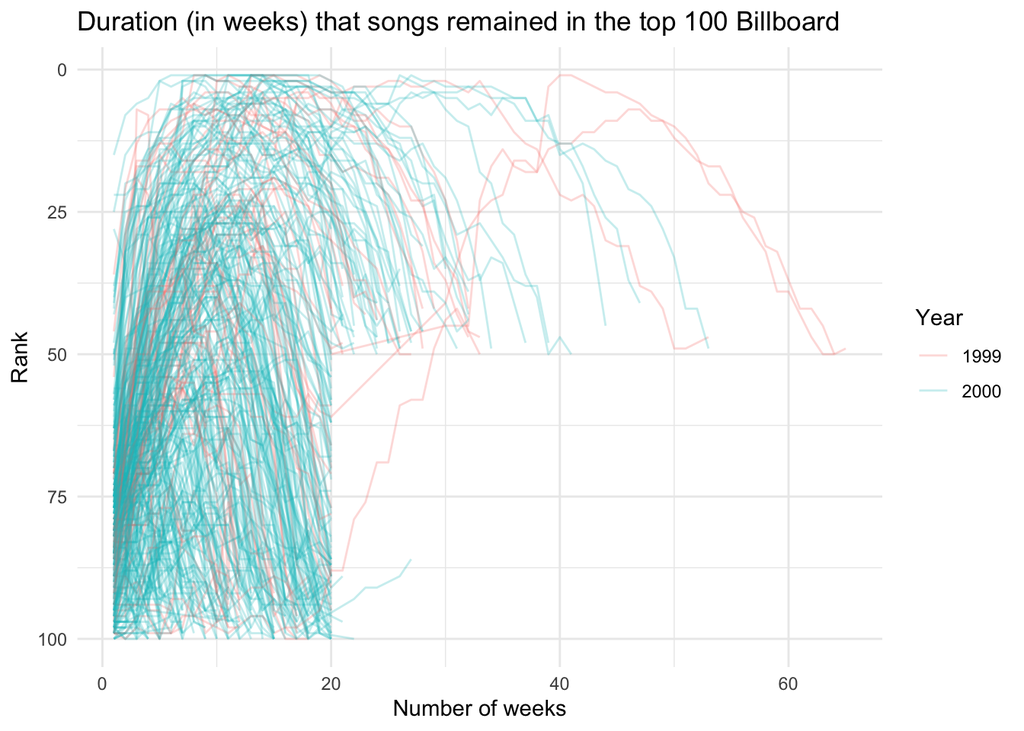

Abbildung 2: Billboard ranks by number of weeks for songs that were in the top 100 in the year 2000

- what is the most number of weeks a song was in the top 100?
- why is 100 at the bottom and 0 at the top?
- why is the bottom right quarter empty? What does this mean?

**Aufgabe 1: Tidy data**

**Beispiel 2**

1. Recreate Abbildung 2.

# 7 Widening data: `df_cms`

- `pivot_wider()` make datasets *wider* by increasing columns and reducing rows
  - this helps when one observation is spread across multiple rows
  - this type of data isn’t very common in the wild, but is pretty common in governmental data
- the `cms_patient_experience.csv` dataset contains data about patient experiences fom the Centers of Medicare and Medicaid services
- the core unit being studied is an organisation (stored in `org_pac_id` and `org_nm`), but each organisation (i.e., observation) takes up 6 rows
  - one row for each measure (i.e., variable)
  - so we want these variables to be represented in columns

| org_pac_id | org_nm | measure_cd | measure_title | prf_rate |
| --- | --- | --- | --- | --- |
| 0446157747 | USC CARE MEDICAL GROUP INC | CAHPS_GRP_1 | CAHPS for MIPS SSM: Getting Timely Care, Appointments, and Information | 63 |
| 0446157747 | USC CARE MEDICAL GROUP INC | CAHPS_GRP_2 | CAHPS for MIPS SSM: How Well Providers Communicate | 87 |
| 0446157747 | USC CARE MEDICAL GROUP INC | CAHPS_GRP_3 | CAHPS for MIPS SSM: Patient's Rating of Provider | 86 |
| 0446157747 | USC CARE MEDICAL GROUP INC | CAHPS_GRP_5 | CAHPS for MIPS SSM: Health Promotion and Education | 57 |
| 0446157747 | USC CARE MEDICAL GROUP INC | CAHPS_GRP_8 | CAHPS for MIPS SSM: Courteous and Helpful Office Staff | 85 |
| 0446157747 | USC CARE MEDICAL GROUP INC | CAHPS_GRP_12 | CAHPS for MIPS SSM: Stewardship of Patient Resources | 24 |

## 7.1 `pivot_wider()`

- takes long data and makes it wider
- takes a few arguments:
  - `id_cols`: identifying columns
  - `names_from`: what should we call the new column containing the previous column names?
  - `names_prefix`: prefix for the new column names
  - `values_from`: new column values
- how can we, for each `org`,
  - take the six values from `measure_cd` and create six new variable `names` `from` them,
  - and take the `values` `from` `prf_rate`?
- the result should look like Tabelle 5

```r
cms_patient_experience %>%
  pivot_wider(
    id_cols = starts_with("org"),
    names_from = measure_cd,
    values_from = prf_rate
  ) %>%
  head() %>%
  knitr::kable() %>%
  kableExtra::kable_styling(font_size = 20)
```

Tabelle 5: Wider `df_cms` data (measure variable to columns with rating as values)

| org_pac_id | org_nm | CAHPS_GRP_1 | CAHPS_GRP_2 | CAHPS_GRP_3 | CAHPS_GRP_5 | CAHPS_GRP_8 | CAHPS_GRP_12 |
| --- | --- | --- | --- | --- | --- | --- | --- |
| 0446157747 | USC CARE MEDICAL GROUP INC | 63 | 87 | 86 | 57 | 85 | 24 |
| 0446162697 | ASSOCIATION OF UNIVERSITY PHYSICIANS | 59 | 85 | 83 | 63 | 88 | 22 |
| 0547164295 | BEAVER MEDICAL GROUP PC | 49 | NA | 75 | 44 | 73 | 12 |
| 0749333730 | CAPE PHYSICIANS ASSOCIATES PA | 67 | 84 | 85 | 65 | 82 | 24 |
| 0840104360 | ALLIANCE PHYSICIANS INC | 66 | 87 | 87 | 64 | 87 | 28 |
| 0840109864 | REX HOSPITAL INC | 73 | 87 | 84 | 67 | 91 | 30 |

- Tabelle 6 shows the first 6 rows of the original dataset

Tabelle 6: Original `cms_patient_experience.csv` format

| org_pac_id | org_nm | measure_cd | measure_title | prf_rate |
| --- | --- | --- | --- | --- |
| 0446157747 | USC CARE MEDICAL GROUP INC | CAHPS_GRP_1 | CAHPS for MIPS SSM: Getting Timely Care, Appointments, and Information | 63 |
| 0446157747 | USC CARE MEDICAL GROUP INC | CAHPS_GRP_2 | CAHPS for MIPS SSM: How Well Providers Communicate | 87 |
| 0446157747 | USC CARE MEDICAL GROUP INC | CAHPS_GRP_3 | CAHPS for MIPS SSM: Patient's Rating of Provider | 86 |
| 0446157747 | USC CARE MEDICAL GROUP INC | CAHPS_GRP_5 | CAHPS for MIPS SSM: Health Promotion and Education | 57 |
| 0446157747 | USC CARE MEDICAL GROUP INC | CAHPS_GRP_8 | CAHPS for MIPS SSM: Courteous and Helpful Office Staff | 85 |
| 0446157747 | USC CARE MEDICAL GROUP INC | CAHPS_GRP_12 | CAHPS for MIPS SSM: Stewardship of Patient Resources | 24 |

- Tabelle 7 shows the first 6 rows of the widened dataset

Tabelle 7: Widened `cms_patient_experience.csv` format

| org_pac_id | org_nm | CAHPS_GRP_1 | CAHPS_GRP_2 | CAHPS_GRP_3 | CAHPS_GRP_5 | CAHPS_GRP_8 | CAHPS_GRP_12 |
| --- | --- | --- | --- | --- | --- | --- | --- |
| 0446157747 | USC CARE MEDICAL GROUP INC | 63 | 87 | 86 | 57 | 85 | 24 |
| 0446162697 | ASSOCIATION OF UNIVERSITY PHYSICIANS | 59 | 85 | 83 | 63 | 88 | 22 |
| 0547164295 | BEAVER MEDICAL GROUP PC | 49 | NA | 75 | 44 | 73 | 12 |
| 0749333730 | CAPE PHYSICIANS ASSOCIATES PA | 67 | 84 | 85 | 65 | 82 | 24 |
| 0840104360 | ALLIANCE PHYSICIANS INC | 66 | 87 | 87 | 64 | 87 | 28 |
| 0840109864 | REX HOSPITAL INC | 73 | 87 | 84 | 67 | 91 | 30 |

- how is the data from Tabelle 6 represented in Tabelle 7?

# 8 Aufgabe

1. Browse the tracks. Choose a song you like (or a song at random), and then
   - filter the data to include only this song, and then
   - create a line plot of the song’s time on the Top 100 Billboard
   - refer to the plot and describe the song’s trend (you’d want to look at the song’s data for this)

An example: *Abbildung 3 shows the trend of ‘Say My Name’ by Destiny’s child, which entered the charts on Dec. 25th, 1999 (`date_entered`) at number 83 (`rank` for `wk1`), and stayed on the top 100 for 32 weeks (`max(week)`).*

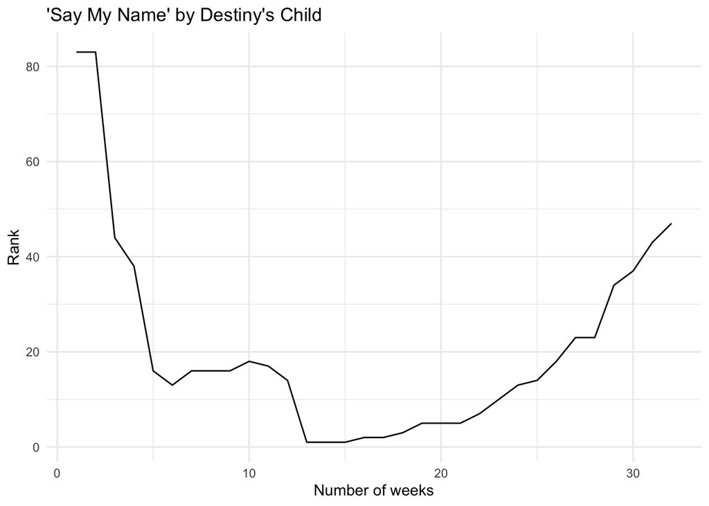

Abbildung 3: Example linegraph for ‘Say My Name’ by Destiny’s Child

2. Load the dataset `biondo_etal_2021_tidy.csv` (subset of data from Biondo et al. (2022)) and save it as `df_biondo`
   - print a formatted table (using `knitr::kable()`) with a `label` and caption of the `head()` of the data
3. Lengthen the data so that the columns `rt` and `tt` are in one column:
   - the variable `names` should go `to` a new variable called `measure`
   - the variable `values` should go `to` a new variable `ms` (for milliseconds)
   - save the lengthened data as `df_biondo_long`
   - print a formatted table (using `knitr::kable()`) with a `label` and caption
4. Widen `df_biondo_long` so that the columns `rt` and `tt` are back in their own columns
   - the `id_cols` should be `subj` and `item`
   - the variable `names` should come `from` `measure`
   - the variable `values` should come `from` `ms` (for milliseconds)
   - save the lengthened data as `df_biondo_wide`
   - print a formatted table (using `knitr::kable()`) with a `label` and caption
   - tip: `df_biondo_wide` should be the exact same as `df_biondo`

# Heutige Ziele 🏁

Heute haben wir…

- learn about wide versus long data ✅
- make wide data longer ✅
- make long data wider ✅
- review the `dplyr` verbs from week 3 ✅

# Session Info

Hergestellt mit R version 4.3.0 (2023-04-21) (Already Tomorrow) und RStudioversion 2023.3.0.386 (Cherry Blossom).

# Literaturverzeichnis

Biondo, N., Soilemezidi, M., & Mancini, S. (2022). Yesterday Is History, Tomorrow Is a Mystery: An Eye-Tracking Investigation of the Processing of Past and Future Time Reference during Sentence Reading. *Journal of Experimental Psychology: Learning, Memory, and Cognition*, *48*(7), 1001–1018. https://doi.org/10.1037/xlm0001053

Nordmann, E., & DeBruine, L. (2022). *Applied Data Skills* (Version 2.0). Zenodo. https://doi.org/10.5281/zenodo.6365078

Wickham, H., Çetinkaya-Rundel, M., & Grolemund, G. (o. J.). *R for Data Science* (2. Aufl.). https://r4ds.hadley.nz/